# Footprinting Analysis

`bash`bash #differential footprint HH6vs HH18 #rgt with HH6 replicates combined and HH18 repliacates samtools merge HH6_combined.bam HH6_1.bam HH6_2.bam samtools index -@ 24 HH6_combined.bam samtools merge HH18_combined.bam HH18_1.bam HH18_2.bam samtools index -@ 24 HH18_combined.bam rgt-hint footprinting –atac-seq –paired-end –organism=gg6 –output-location=./ –output-prefix=HH6_combined HH6_combined.bam all_ATAC_400bp_fixed.bed rgt-hint footprinting –atac-seq –paired-end –organism=gg6 –output-location=./ –output-prefix=HH18_combined HH18_combined.bam all_ATAC_400bp_fixed.bed rgt-motifanalysis matching –organism=gg6 –input-files HH6_combined.bed HH18_combined.bed rgt-hint differential –organism=gg6 –bc –nc 30 –mpbs-files=./match/HH6_combined_mpbs.bed,./match/HH18_combined_mpbs.bed –reads-files=HH6_combined.bam,HH18_combined.bam –conditions=HH6_combined,HH18_combined –output-location=HH6_vs_HH18

#HH8 vs HH18 samtools merge HH8_combined.bam HH8_1.bam HH8_2.bam samtools index -@ 24 HH8_combined.bam rgt-hint footprinting –atac-seq –paired-end –organism=gg6 –output-location=./ –output-prefix=HH8_footprint HH8_combined.bam all_ATAC_400bp_fixed.bed rgt-motifanalysis matching –organism=gg6 –input-files HH8_footprint.bed HH18_combined.bed rgt-hint differential –organism=gg6 –bc –nc 30 –mpbs-files=./match/HH8_footprint_mpbs.bed,./match/HH18_combined_mpbs.bed –reads-files=HH8_combined.bam,HH18_combined.bam –conditions=HH8_combined,HH18_combined –output-location=HH8_vs_HH18

```r
#making differential motif volcano plot
library(readr)
setwd("/data/Austin/workdir/NC_Timecourse_Data/Debbie_exports/Fig1/HH6_vs_HH18")
```

```
The working directory was changed to /data/Austin/workdir/NC_Timecourse_Data/Debbie_exports/Fig1/HH6_vs_HH18 inside a notebook chunk. The working directory will be reset when the chunk is finished running. Use the knitr root.dir option in the setup chunk to change the working directory for notebook …
```

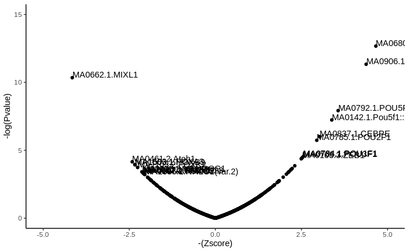

```r
differential_statistics_6vs18 <- read_delim("differential_statistics_6vs18.csv",
    "\t", escape_double = FALSE, trim_ws = TRUE)
View(differential_statistics_6vs18)
Differential_motif = data.frame(differential_statistics_6vs18$Motif, differential_statistics_6vs18$TF_Activity, differential_statistics_6vs18$Z_score,differential_statistics_6vs18$P_values)
colnames(Differential_motif) = c("Motif","TF_activity","Zscore","Pvalue")
ggplot(Differential_motif, aes(y =-log(Pvalue), x =-(Zscore))) + geom_point() + ylim(0,15) +xlim(-5,5) +  geom_text(aes(label=ifelse(-Zscore>= 2.5,as.character(Motif),'')),hjust=0,vjust=0) + geom_text(aes(label=ifelse(Zscore>=2,as.character(Motif),'')),hjust=0,vjust=0) +theme_classic()
```